# Ski Data Preparation

Import Sales Data

`r`r library(readr) sales_data <- read_csv(~/Documents/School/Masters/MMAi Queens/Semester 1/MMAI863/Assignments/A1/R App/ski-lodge/data/sales_data.csv)

Googlesheets will be used for persistent storgae

`r`r library(googlesheets) suppressMessages(library(dplyr))

Prepare sheet details

[output not shown]

Adding Season Information

`r`r sales_data$year <- strtoi(format(sales_data$date, %Y)) sales_data$month <- strtoi(format(sales_data$date, %m)) sales_data$yrmonth <- strtoi(format(sales_data$date, %Y%m)) yrmonth <- unique(sales_data$yrmonth) season_end <- (unique(sales_data$year) + 1) *100 +5 sales_data$season <- 0 for (i in 1:nrow(sales_data)){ for (j in 1:length(season_end)){ if (sales_data$yrmonth[i] < season_end[j] && sales_data$season[i] == 0){ sales_data$season[i] <- j } } }

Add Preliminary sales data

`r`r gs_ws_new(gap, ‘sales_data’, input = sales_data, trim = TRUE)

```
Worksheet \sales_data\ added to sheet \sales_weather_data\.
Range affected by the update: \R1C1:R508C6\
Worksheet \sales_data\ successfully updated with 3048 new value(s).
Accessing worksheet titled 'sales_data'.
Sheet successfully identified: \sales_weather_data\
Accessing worksheet titled 'sales_data'.
Worksheet \sales_data\ dimensions changed to 508 x 6.
Worksheet dimensions: 508 x 6.
```

Prepare Data

[output not shown]

Add Summary Metrics - Profit & Days

`r`r d$n_rev <- 0 d$p_rev <- 0 d$n_retCost <- 0 d$p_retCost <- 0 d$n_cost <- 0 d$p_cost <- 0 d$n_inst <- 0 d$p_inst <- 0 d$days_open <- 0 d$days_season <- 0 d$days_ostaffed <- 0 d$days_snow <- 0 d$snow_on_grnd_cm[is.na(d$snow_on_grnd_cm)] <- mean(d$snow_on_grnd_cm, na.rm = TRUE) d$n_rev[d$promotion == 0] <- d$lessons[d$promotion == 0] * 549 d$p_rev[d$promotion == 1] <- d$lessons[d$promotion == 1] * 499 d$n_retCost[d$promotion == 0] <- (20 - d$lessons[d$promotion == 0]) * 100 d$p_retCost[d$promotion == 1] <- (36 - d$lessons[d$promotion == 1]) * 100 d$n_cost[d$promotion == 0] <- d$lessons[d$promotion == 0] * 549/2 d$p_cost[d$promotion == 1] <- d$lessons[d$promotion == 1] * 499/2 d$n_inst[d$promotion == 0] <- 20 d$p_inst[d$promotion == 1] <- 36 d$days_open[d$lessons > 0] <- 1 d$days_season[d$season > 0] <- 1 d$total_cost <- (d$n_cost + d$p_cost + d$n_retCost + d$p_retCost) d$total_revenue <- (d$n_rev + d$p_rev) d$profit <- d$total_revenue - d$total_cost d$total_inst <- d$n_inst + d$p_inst d$days_ostaffed [d$total_inst > d$lessons] <- 1 d$days_snow [d$snow_on_grnd_cm > 15] <- 1 d$mean_temp_c_factor <- 2 * d$mean_temp_c

Create summary

`r`r k <- d %>% group_by(season, DoW, month, year, promotion) %>% summarise(total_cost = sum(total_cost), n_cost = sum(n_cost), p_cost = sum(p_cost), n_retCost = sum(n_retCost), p_retCost = sum(p_retCost), total_revenue = sum(total_revenue), n_rev = sum(n_rev), p_rev = sum(p_rev), profit = sum(profit), total_inst = sum(total_inst), n_inst = sum(n_inst), p_inst = sum(p_inst), lessons = sum(lessons), days_open = sum(days_open), days_season = sum(days_season, na.rm = TRUE), days_snow = sum(days_snow, na.rm=TRUE), days_ostaffed = sum(days_ostaffed), total_snow_cm = sum(total_snow_cm, na.rm=TRUE), snow_on_grnd_cm = sum (snow_on_grnd_cm, na.rm=TRUE), mean_temp_c_factor = sum(mean_temp_c_factor, na.rm=TRUE) )

Upload new sheet

`r`r gs_ws_new(gap, ‘summary’, input = k, trim = TRUE)

```
Auto-refreshing stale OAuth token.
Worksheet \summary\ added to sheet \sales_weather_data\.
Range affected by the update: \R1C1:R186C25\
```

Prepare data for modelling

`r`r model_data<- d %>% group_by(season, DoW, month, year, promotion) %>% summarise(lessons = sum(lessons), mean_temp_c_factor = sum(mean_temp_c_factor), snow_on_grnd_cm = sum(snow_on_grnd_cm), total_snow_cm = sum(total_snow_cm), days_season = sum(days_season) )

`r`r library(stats) m_temp <- mean(model_data$mean_temp_c_factor/ model_data$days_season, na.rm = TRUE) s_temp <- sd(model_data$mean_temp_c_factor/ model_data$days_season, na.rm = TRUE) n_temp <- length(model_data$mean_temp_c_factor) m_snow <- mean(model_data$snow_on_grnd_cm/ model_data$days_season, na.rm = TRUE) s_snow <- sd(model_data$snow_on_grnd_cm/ model_data$days_season, na.rm = TRUE) n_snow <- length(model_data$snow_on_grnd_cm)

Assess the distribution of Snow on the ground and fitness of normal function

`r`r h <- hist(model_data$snow_on_grnd_cm/model_data$days_season, breaks = 13)

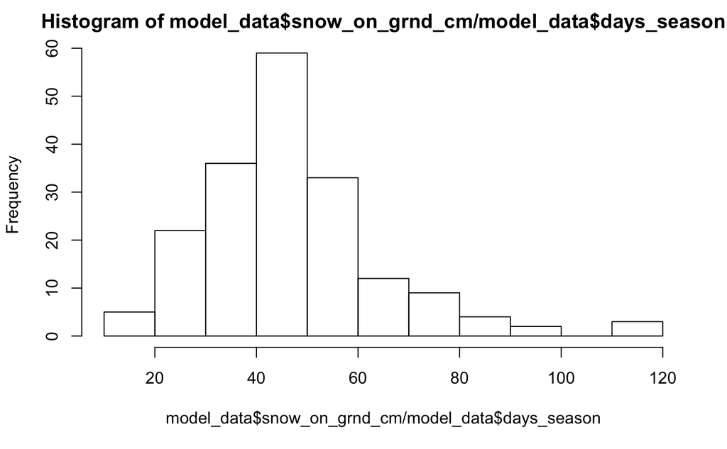

`r`r xhist<-c(min(h$breaks),h$breaks) yhist<-c(0,h$density,0) x.norm<-rnorm(n=n_snow,m=m_snow,sd=s_snow) xfit<-seq(min(x.norm),max(x.norm),length=50) yfit<-dnorm(xfit,mean=mean(x.norm),sd=sd(x.norm)) plot(xhist,yhist,type=‘s’,ylim=c(0,max(yhist,yfit)), main=‘Avg. Snow on Ground Normal Fit’ , xlab = ‘Snow in cm’, ylab = ‘Probability’) lines(xfit,yfit, col=‘red’)

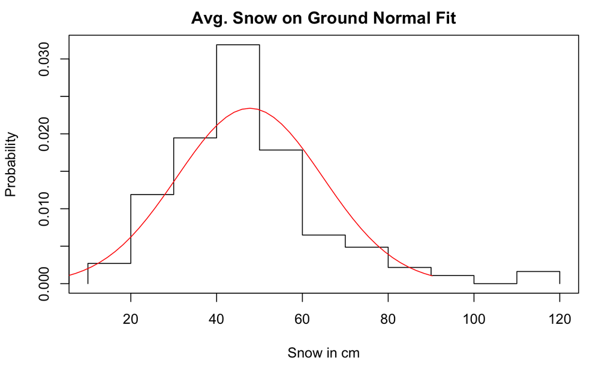

[output not shown]

`r`r h <- hist(model_data$mean_temp_c_factor/model_data$days_season, breaks = 13)

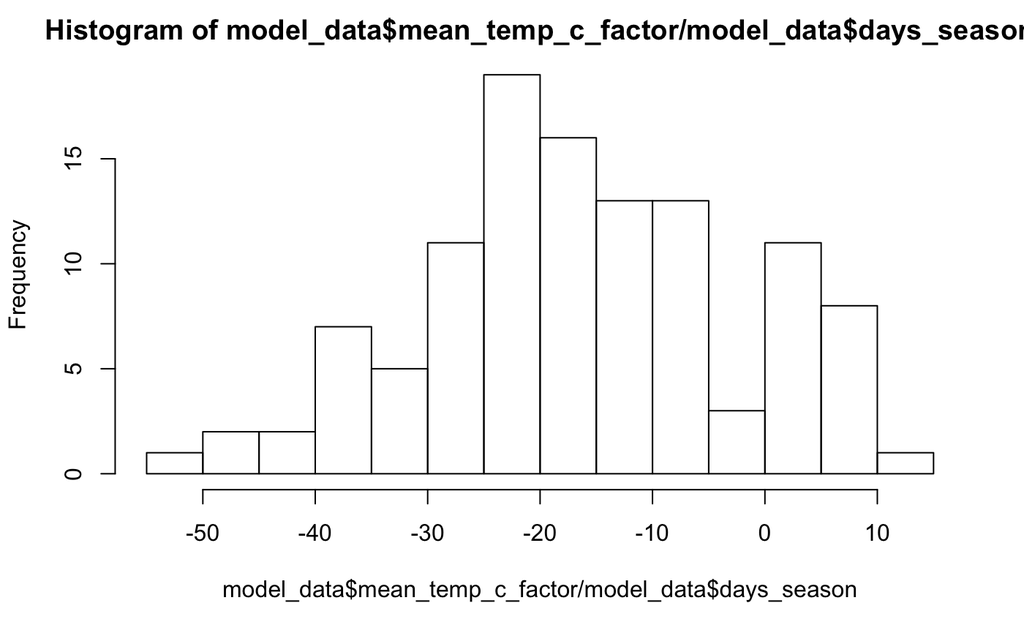

`r`r xhist<-c(min(h$breaks),h$breaks) yhist<-c(0,h$density,0) x.norm<-rnorm(n=n_temp,m=m_temp,sd=s_temp) xfit<-seq(min(x.norm),max(x.norm),length=50) yfit<-dnorm(xfit,mean=mean(x.norm),sd=sd(x.norm)) plot(xhist,yhist,type=‘s’,ylim=c(0,max(yhist,yfit)), main=‘Avg. Temperature Normal Fit’ , xlab = ‘Temperature in °C’, ylab = ‘Probability’) lines(xfit,yfit, col=‘red’)

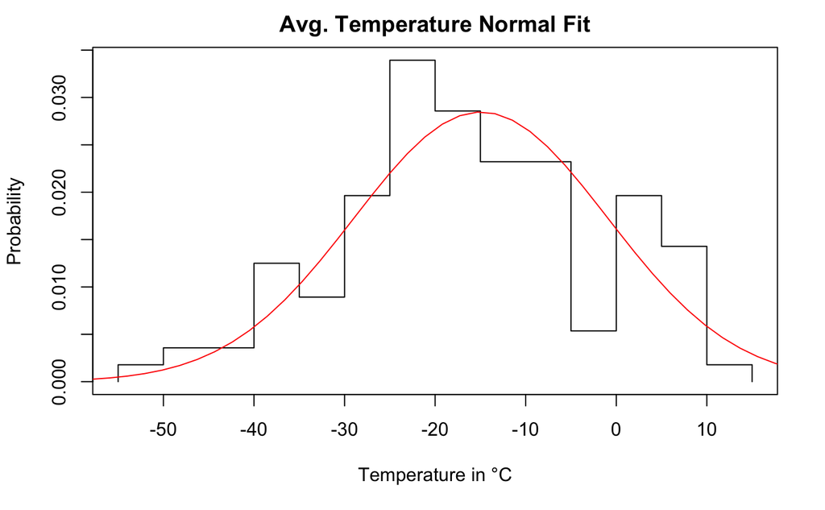

`r`r model <- lm(lessons ~ snow_on_grnd_cm + mean_temp_c_factor + DoW + month + promotion + days_season, data = model_data)

`r`r summary(model)

```
Call:
lm(formula = lessons ~ snow_on_grnd_cm + mean_temp_c_factor +
    DoW + month + promotion + days_season, data = model_data)

Residuals:
     Min       1Q   Median       3Q      Max
-20.0427  -5.8943   0.3001   5.9698  17.3548

Coefficients:
                     Estimate Std. Error t value Pr(>|t|)
(Intercept)         -0.933514   3.991001  -0.234 0.815537
snow_on_grnd_cm      0.003332   0.021624   0.154 0.877853
mean_temp_c_factor   0.022106   0.029602   0.747 0.456954
DoWTuesday         -11.599219   3.089388  -3.755 0.000292 ***
DoWWednesday        -6.081120   3.186462  -1.908 0.059204 .
DoWThursday         -0.409255   3.009984  -0.136 0.892122
DoWFriday           11.307198   3.013120   3.753 0.000294 ***
DoWSaturday         15.095211   2.874372   5.252 8.51e-07 ***
DoWSunday           10.975632   3.014355   3.641 0.000432 ***
month                0.313330   0.271689   1.153 0.251549
promotion            5.381051   2.741020   1.963 0.052406 .
days_season         12.172209   1.553107   7.837 5.08e-12 ***
---
Signif. codes:  0 ‘***’ 0.001 ‘**’ 0.01 ‘*’ 0.05 ‘.’ 0.1 ‘ ’ 1

Residual standard error: 8.297 on 100 degrees of freedom
  (73 observations deleted due to missingness)
Multiple R-squared:  0.8197,    Adjusted R-squared:  0.7999
F-statistic: 41.34 on 11 and 100 DF,  p-value: < 2.2e-16
```

Prepare parameters sheet

`r`r library(broom) g<-cbind(t(data.frame(model$coefficients)), data.frame(m_snow, m_temp, s_snow, s_temp)) gs_ws_new(gap, ‘model_parameters’, input = g, trim = TRUE)

```
Worksheet \model_parameters\ added to sheet \sales_weather_data\.
Range affected by the update: \R1C1:R2C16\
Worksheet \model_parameters\ successfully updated with 32 new value(s).
Accessing worksheet titled 'model_parameters'.
Sheet successfully identified: \sales_weather_data\
Accessing worksheet titled 'model_parameters'.
Worksheet \model_parameters\ dimensions changed to 2 x 16.
Worksheet dimensions: 2 x 16.
```

Clear memory

`r`r rm(list=ls(all=TRUE))

```r
rsconnect::deployApp('~/Documents/School/Masters/MMAi Queens/Semester 1/MMAI863/Assignments/A1/R App/ski-lodge/')
```

```
Preparing to deploy application...
```

```r
y
```

```
DONE
Uploading bundle for application: 497081...DONE
Deploying bundle: 1640840 for application: 497081 ...
Waiting for task: 557090925
  building: Parsing manifest
  building: Building image: 1681681
  building: Fetching packages
  building: Installing packages
  building: Installing files
  building: Pushing image: 1681681
  deploying: Starting instances
  rollforward: Activating new instances
  terminating: Stopping old instances
Application successfully deployed to https://csehdz.shinyapps.io/ski-lodge/
```

Model Backup

```
# Filter days of interest
x <- model_dates[model_dates$Date >= start_Date,]
x <- x[x$Date <= end_Date,]
x$count <- 1

# Summarize all concepts
y<- x %>%
  group_by(DoW, Month, Year, Day_Num) %>%
  summarise(count = sum(count))
size <- nrow(y)

# Calculate n = size values from normal dist
y$snow_avg <- c(rnorm(size, p$m_snow, p$s_snow))
y$temp_avg <- c(rnorm(size, p$m_temp, p$s_temp))

# Calculate total factors
y$snow <- y$snow_avg * y$count
y$temp <- y$temp_avg * y$count

# Assign factors to week vector
week <- c(0, p$DoWTuesday, p$DoWWednesday, p$DoWThursday,
          p$DoWFriday, p$DoWSaturday, p$DoWSunday)

# Calculate lessons
y$f_int <- as.numeric(p['(Intercept)'])
y$f_days <- p$days_season * y$Day_Num
y$f_snow <- p$snow_on_grnd_cm * y$snow
y$f_temp <- p$mean_temp_c_factor * y$temp
y$f_month <- p$month * y$Month
y$f_DoW <- week[y$Day_Num]
y$lessons <- y$f_int + y$f_days + y$f_snow + y$f_temp +y$f_month +y$f_DoW
inst <- ceiling(max(y$lessons/y$Day_Num))
y$profit <- 549/2 * y$lessons - 100*(inst * y$Day_Num - y$lessons)
y$inst <- inst

# 'This Season', 'by Month', 'by Week', 'by Weekday'
group <- grouping()

y <- y %>%
  group_by(!!group) %>%
  summarize_all(mean)
y
```

`r`r sample(1:10, 1)

```
[1] 8
```